# Discretisation with Decision Trees

Discretisation with Decision Trees consists in using a decision tree to identify the optimal bins. When a decision tree makes a decision, it assigns an observation to one of n end leaves. Therfore, any decision tree will generate a discrete output, which values are the predictions at each of its n leaves.

How to do discretisation with trees?

- 1) Train a decision tree of limited depth (2, 3 or 4) using the variable we want to discretise and the target
- 2) Replace the values by th eoutput returned by the tree.

## Advantages

- The output returned by the decision tree is monotonically related to the target.
- The tree end nodes, or bins in the discretised variable ahow decreased entropy: that is, the observations within each bin are more similar among themselves than to those of other bins.

## Limitations

- Prone over-fitting
- More importantly, some tuning of the tree parameters neede to obtain the optimal number of splits(e.g tree depth, minimum number of samples in one partition, maximum number of partitions, and a minimum information gain). Thus it can be time consuming.

```python
import pandas as pd
import numpy as np

import matplotlib.pyplot as plt

from sklearn.model_selection import train_test_split

from sklearn.tree import DecisionTreeClassifier, export_graphviz
from sklearn.model_selection import cross_val_score
```

```python
data = pd.read_csv('../data/titanic.csv',
                  usecols = ['age', 'fare', 'survived'])

data.head()
```

|  | survived | age | fare |
| --- | --- | --- | --- |
| 0 | 1 | 29.0000 | 211.3375 |
| 1 | 1 | 0.9167 | 151.5500 |
| 2 | 0 | 2.0000 | 151.5500 |
| 3 | 0 | 30.0000 | 151.5500 |
| 4 | 0 | 25.0000 | 151.5500 |

```python
X_train, X_test, y_train, y_test = train_test_split(
    data[['age', 'fare']],
    data['survived'],
    test_size=0.3,
    random_state=192)

X_train.shape, X_test.shape
```

```
((916, 2), (393, 2))
```

```python
X_train.fillna(X_train.mean(), inplace=True)
X_test.fillna(X_train.mean(), inplace=True)
```

```python
# example: build classification tree using age to predict survived

tree_model = DecisionTreeClassifier(max_depth=3)

tree_model.fit(X_train['age'].to_frame(), y_train)

X_train['Age_tree'] = tree_model.predict_proba(X_train['age'].to_frame())[:,1]

X_train.head()
```

|  | age | fare | Age_tree |
| --- | --- | --- | --- |
| 819 | 29.435223 | 7.7500 | 0.337600 |
| 870 | 27.000000 | 7.9250 | 0.337600 |
| 959 | 32.000000 | 7.9250 | 0.337600 |
| 185 | 42.000000 | 26.5500 | 0.463542 |
| 644 | 40.000000 | 31.3875 | 0.463542 |

```python
# let's explore how many end points the tree created

X_train['Age_tree'].unique()
```

```
array([0.3376    , 0.46354167, 0.78571429, 0.60714286, 0.21621622,
       0.        , 1.        , 0.33333333])
```

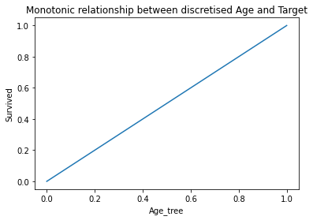

```python
# monotonic relatiosnhip withh target

pd.concat([X_train, y_train], axis=1).groupby(['Age_tree'])['survived'].mean().plot()
plt.title('Monotonic relationship between discretised Age and Target')
plt.ylabel('Survived')
```

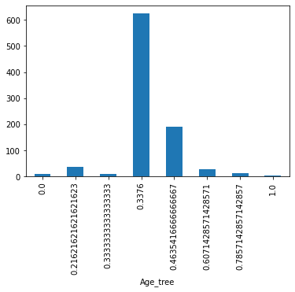

```python
# number of passengers per probabilistic bucket / bin

X_train.groupby(['Age_tree'])['age'].count().plot.bar()
```

```python
# let's see the Age limits buckets generated by the tree
# by capturing the minimum and maximum age per each probability bucket
# we get an idea of the bucket cut-offs

pd.concat([X_train.groupby(['Age_tree'])['age'].min(),
          X_train.groupby(['Age_tree'])['age'].max()], axis=1)
```

| Age_tree | age | age |
| --- | --- | --- |
| 0.000000 | 34.0000 | 34.5000 |
| 0.216216 | 55.5000 | 80.0000 |
| 0.333333 | 2.0000 | 2.0000 |
| 0.337600 | 9.0000 | 33.0000 |
| 0.463542 | 35.0000 | 55.0000 |
| 0.607143 | 3.0000 | 8.0000 |
| 0.785714 | 0.7500 | 1.0000 |
| 1.000000 | 0.1667 | 0.6667 |

Thus, the decision tree generated the buckets: 34-34.5, 55-80, 2-2, 9-33, 35-55, 3-8, 0.75-1, 0.16-0.66, with probabilities of survival 0, 0.21, 0.33, 0.337, 0.46, 0.60, 0.78, 1 respectively.

## Building the optimal decision tree

There are a number of parameters that we could optimise to obtain the best bin split using decison trees.

I will optimise th etree depth for this demonstration. But we can optimise other parameters too.

```python
# build trees of different depths, and calculate the roc-auc of each tree
# choose the depth that generates the best roc-auc

score_1s = [] # here we store the roc auc
score_std_1s = [] # here we store the standard deviation of the roc auc


for tree_depth in [1, 2, 3, 4]:

    # call the model
    tree_model = DecisionTreeClassifier(max_depth=tree_depth)

    # train the model using 3 fold cross validation

    scores = cross_val_score(
         tree_model, X_train['age'].to_frame(), y_train, cv=3, scoring='roc_auc')

    score_1s.append(np.mean(scores))
    score_std_1s.append(np.std(scores))

# capture the parameters in a dataframe
temp = pd.concat([pd.Series([1, 2, 3, 4]), pd.Series(
       score_1s), pd.Series(score_std_1s)], axis=1)

temp.columns = ['depth', 'roc_auc_mean', 'roc_auc_std']
temp
```

|  | depth | roc_auc_mean | roc_auc_std |
| --- | --- | --- | --- |
| 0 | 1 | 0.524955 | 0.015493 |
| 1 | 2 | 0.526654 | 0.016068 |
| 2 | 3 | 0.532456 | 0.028020 |
| 3 | 4 | 0.530061 | 0.017697 |

## Transform the feature using tree

```python
tree_model = DecisionTreeClassifier(max_depth=2)

tree_model.fit(X_train['age'].to_frame(), y_train)

X_train['Age_tree'] = tree_model.predict_proba(X_train['age'].to_frame())[:,1]
X_test['Age_tree'] = tree_model.predict_proba(X_test['age'].to_frame())[:,1]
```

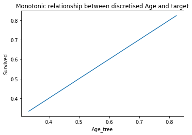

```python
# monotonic relationship with target in train set

pd.concat([X_train, y_train], axis=1).groupby(['Age_tree'])['survived'].mean().plot()
plt.title('Monotonic relationship between discretised Age and target')
plt.ylabel('Survived')
```

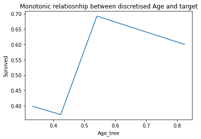

```python
# in the test set

X_test['Age_tree'] = tree_model.predict_proba(X_test['age'].to_frame())[:,1]

# monotonic relatiosnhip with target
pd.concat([X_test, y_test], axis=1).groupby(['Age_tree'])['survived'].mean().plot()
plt.title('Monotonic relatiosnhip between discretised Age and target')
plt.ylabel('Survived')
```

The montonic relationship is not totally maintained in the test. We could try and optimise the decision tree further to see if we can keep the monotonic relatiosnhip. Or alternatively, directly test the model performance with these engineered features and see if they add any value.